# Free Will and Language: Network Analysis

Li Ying

1 July 2015

### Executive Summary

- This report performed exploratory analysis on language pattern produced by two groups of people: `High Free Will Group` and `Low Free Will Group` (refer to as High Group (HG) and Low Group (LG) in the following text)
- Word Cloud, Minimum spanning tree, hierarchical clustering graph, and association network were plotted.
- In the end, statistical test were performed on parameters of association network using *partial network analysis / bootstrape with 1000 iteration*. Detailed steps can be found in the appendix.
- Statistical testing method refers to paper written by [Kenett, Gold and Faust( 2015)](http://scottbarrykaufman.com/wp-content/uploads/2015/06/Kenett-Gold-and-Faust-2015.pdf). Parameters of association network includes: **Diameter(D)**, [Clustering Coefficient(CC)](http://mathinsight.org/definition/clustering_coefficient), [Average Path Length(APL)](http://mathinsight.org/definition/network_mean_path_length). The detailed definition of these concepts can be found in the `appendix`.

#### We found that:

- t-test shows that D and APL are significantally different between EG and IG (p.value<0.001), while CC does not show statistic significance.

### Data

- Participant number: 33
- `Free Will`: 10 questions *subsetted* from *Free Will and Determinism Scale* ([Rakos et al. 2008](http://agencyandresponsibility.typepad.com/files/competing-free-will-and-responsibility-scales.pdf))
- `Free Association task`: each participants were given 73 **cue words**. For each of cue words, they were instructed to write down 3 words/**responses** that they think is most relevant to the **cue words**. The result will be mentioned as **word data** in the following text.

### Data Process

1. Group participants into two categories: *high free will group* and *low free will group* using mean of Free Will Scale as cut-off line.
2. Split word association data into two: those generated by High free will group and Low free will group
3. Clean word data. Steps includes:
   - change all capital letter to lower case
   - remove all numbers, stop words
   - stem words, so that various forms derived from a stem would be taken as the same when counting word frequency
4. Build term-document matrix. Each row represent a response and each column represent a cue word, and entry is number of occurrence of the response in cue words.

### Exploratory Data Analysis

#### Correlational Table

Correlation Table of cue words. Most correlations are very small (less than 0.2).

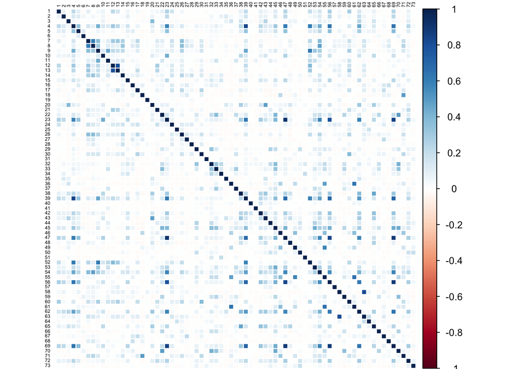

#### Word Cloud

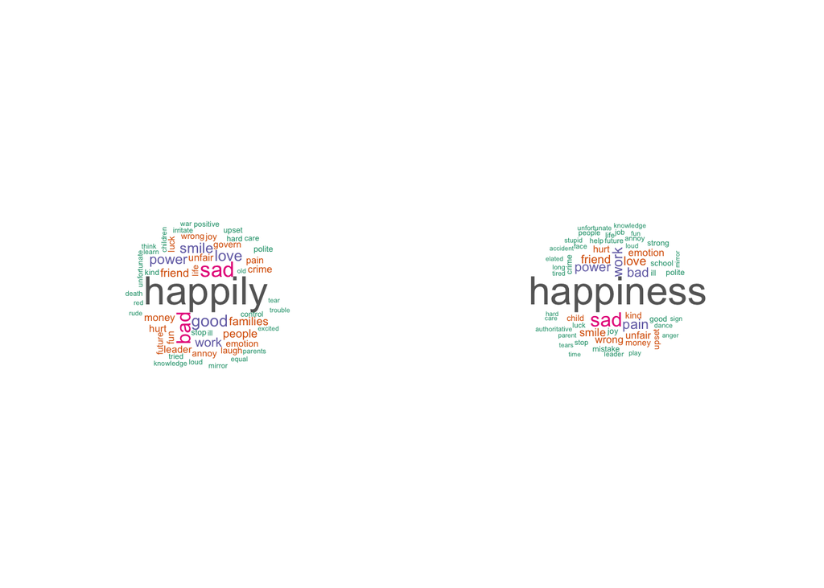

```r
par(mar=c(5,2,1,1))
par(mfrow=c(1,2))
cloud(Hfreq)
cloud(Lfreq)
```

#### Clustering Analysis (single linkage) **Another way of presenting MST**

Cluster Dendrogram were plotted. Both groups shows that most of the clue words merges at a high y-axis, suggesting similarity between clue words are quite low.

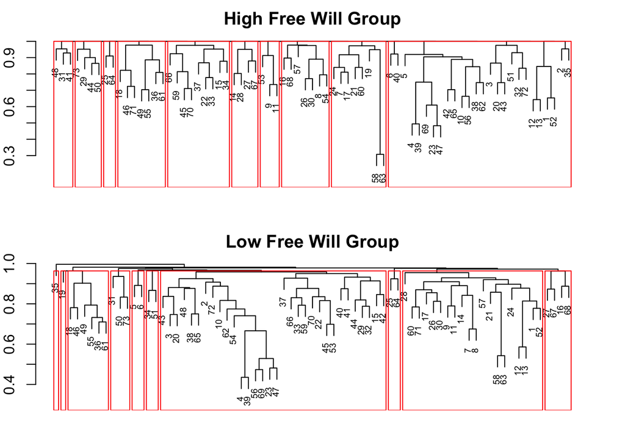

### Minimum Spanning Trees (MST)

Two groups were different by qualitative examination of the MST visualization. The graph of Low Free Will Group looks more modular while the High Free Will Group looks more spread out.

```
## Initial stress        : 0.04088
## stress after  10 iters: 0.02553, magic = 0.092
## stress after  20 iters: 0.02033, magic = 0.338
## stress after  30 iters: 0.01971, magic = 0.500
## stress after  40 iters: 0.01940, magic = 0.500
## stress after  50 iters: 0.01931, magic = 0.500
```

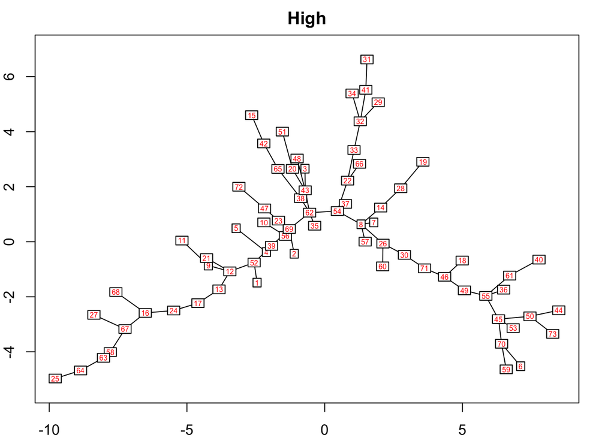

```
## Initial stress        : 0.05823
## stress after  10 iters: 0.03678, magic = 0.461
## stress after  20 iters: 0.03031, magic = 0.213
## stress after  30 iters: 0.02269, magic = 0.500
## stress after  40 iters: 0.02247, magic = 0.500
## stress after  50 iters: 0.02236, magic = 0.500
## stress after  60 iters: 0.02235, magic = 0.500
```

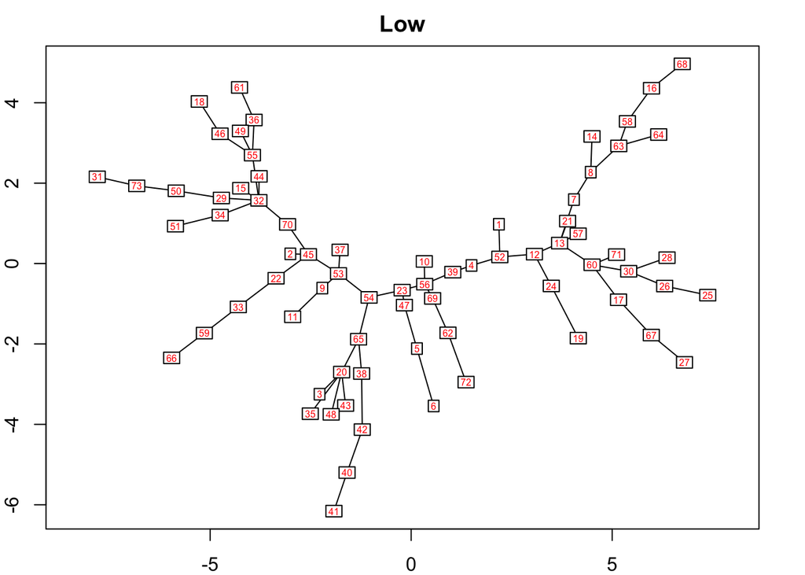

#### Association Network Graph

- Association Network were only plotted on those cue words that have correlation > 0.2
- The edge were colored according to correlational strength between nodes, followed sequence of red, blue and grey representing correlation >0.5, >0.4, and else.
- The length of edge is weighted by correlational strength between nodes.

Method: [Tutorial](http://stackoverflow.com/questions/19965600/igraph-r-how-to-create-correlation-network-with-only-strong-r-values)

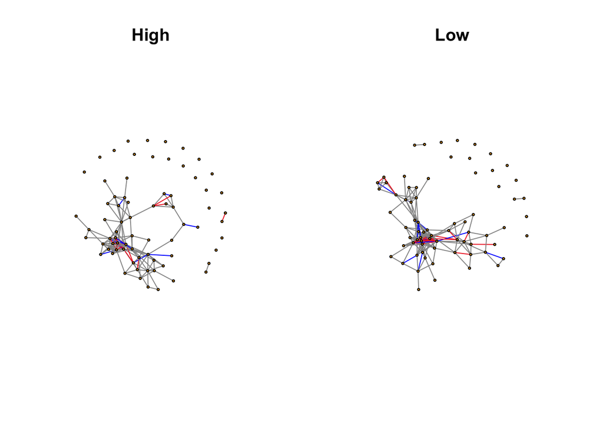

##### Network parameters from HIGH and LOW groups were calculated:

```
##               High      Low
## APL      2.8720456 2.911154
## Diameter 2.0094469 2.255147
## CC       0.5481002 0.555668
## Degree   4.1369863 5.424658
```

##### Degree distribution

Most of node do not have a lot edges with other node. But there were some nodes have lots of edges with others. Those nodes were hubs in the network that connects different clusters.

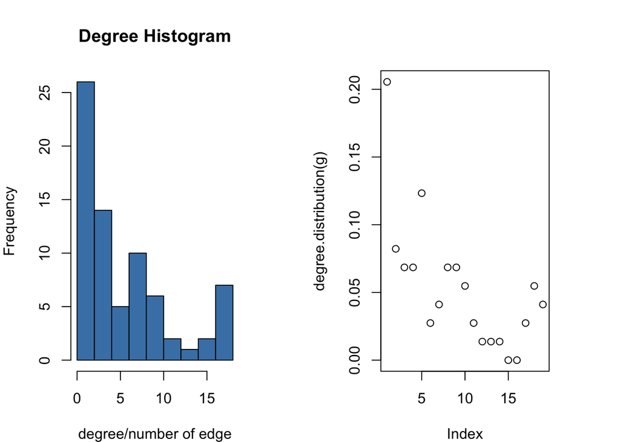

```r
par(mar=c(4,4,4,4))
par(mfrow=c(1,2))
hist(degree(g),col="steelblue", main="Degree Histogram", xlab="degree/number of edge")
plot(degree.distribution(g))
```

#### Statistical text on association network graph

##### Summary:

```
##     High.Mean   Low.Mean
## APL "2.3063406" "2.5228276"
## D   "1.5186535" "1.8677746"
## CC  "0.4981273" "0.5070336"
##     p.value
## APL "0.00000000000000000000386395"
## D   "0.000000000000000000000000000000000000000000000000000000000000000270773"
## CC  "0.131892"
```

#### Detailed t-test result

```
##
##  Welch Two Sample t-test
##
## data:  comAPL[, 1] and comAPL[, 2]
## t = -9.5436, df = 1997, p-value < 2.2e-16
## alternative hypothesis: true difference in means is not equal to 0
## 95 percent confidence interval:
##  -0.2609736 -0.1720004
## sample estimates:
## mean of x mean of y
##  2.306341  2.522828
```

```
##
##  Welch Two Sample t-test
##
## data:  comD[, 1] and comD[, 2]
## t = -17.587, df = 1912, p-value < 2.2e-16
## alternative hypothesis: true difference in means is not equal to 0
## 95 percent confidence interval:
##  -0.3880530 -0.3101893
## sample estimates:
## mean of x mean of y
##  1.518653  1.867775
```

```
##
##  Welch Two Sample t-test
##
## data:  comCC[, 1] and comCC[, 2]
## t = -1.5073, df = 1942.9, p-value = 0.1319
## alternative hypothesis: true difference in means is not equal to 0
## 95 percent confidence interval:
##  -0.020494564  0.002681813
## sample estimates:
## mean of x mean of y
## 0.4981273 0.5070336
```

### Appendix

##### Statistical testing on association network:

- “Second, we examined whether differences between the parameters of two association networks were statistically significant by applying the bootstrap method (Efron, 1979) to simulate partial random External and Internal networks and compared these networks (Kenett et al., 2013; Kenett, Anaki, et al., 2014). This procedure had a twofold rationale:
  - if the two networks truly differ from each other, then any sub-network consisting of the same nodes in both networks should also be different; and
  - the bootstrap method enables the generation of many simulated partial External and External networks, allowing for statistical examination of the difference between the two networks.
- In order to conduct the bootstrapping procedure, half of the cue words (nodes) were randomly chosen. Then partial external and internal networks were constructed separately using these random nodes, based on the entire sample. This method is known as the without replacement bootstrap (Bertail, 1997; Politis & Romano, 1994; Shao, 2003). Finally, for each partial AS and MC network, CC, ASPL,and D measures were computed. This procedure was simulated with 1000 realizations."

#### Terms:

[Degree](http://mathinsight.org/degree_distribution)  
[Unweighted Adjacency Matrix](http://mathinsight.org/definition/adjacency_matrix)  
[Small Word Network](http://mathinsight.org/small_world_network): Featured by large clustering coefficient and small average path length  
[Transitivity](http://mathinsight.org/evidence_additional_structure_real_networks#transitivity)  
[Transitivity math](http://mathinsight.org/definition/transitivity_graph)  
[Clustering Coefficient](http://mathinsight.org/definition/clustering_coefficient)  
[Free Will Scale Scoring Document](http://agencyandresponsibility.typepad.com/files/competing-free-will-and-responsibility-scales.pdf)  
[Minimum Spanning Tree Tutorial](http://cc.oulu.fi/~jarioksa/opetus/metodi/vegantutor.pdf)  
[Average Path Length](http://mathinsight.org/definition/network_mean_path_length)